## Project: Finance

# Exploratory Data Analysis

## 2) Data Exploration

- Import and read the dataset.

```r
df.boston <-read.csv("/content/Boston.csv", header = TRUE)
```

Attributes Description:

Crim: per capita crime rate by town.

zn: proportion of residential land zoned for lots over 25,000 sqft.

indus: proportion of non-retail business acres per town.

chas: charles river dummy variable (= 1 if tract bounds river; 0 otherwise)

nox: nitrogenoxide concentration (parts per 10 million)

rm: average number of rooms per dwelling.

age: proportion of owner occupied units built prior to 1940.

dis: weighted mean of distances to five Boston employment centers.

rad: index of accessibility to radial highways.

tax: full value property-tax rate per $10000.

ptratio: student to teacher ratio by town.

black: 1000(Bk - 0.63)^2 where Bk is the proportion of blacks by town.

lstat: lower status of the population(percent).

medv: median value of owner-occupied homes in $1000s.

- This code print the top 6 rows of the data.

```r
head(df.boston)
```

A data.frame: 6 × 15

|  | X <int> | crim <dbl> | zn <dbl> | indus <dbl> | chas <int> | nox <dbl> | rm <dbl> | age <dbl> | dis <dbl> | rad <int> | tax <int> | ptratio <dbl> | black <dbl> | lstat <dbl> | medv <dbl> |
| --- | --- | --- | --- | --- | --- | --- | --- | --- | --- | --- | --- | --- | --- | --- | --- |
| 1 | 1 | 0.00632 | 18 | 2.31 | 0 | 0.538 | 6.575 | 65.2 | 4.0900 | 1 | 296 | 15.3 | 396.90 | 4.98 | 24.0 |
| 2 | 2 | 0.02731 | 0 | 7.07 | 0 | 0.469 | 6.421 | 78.9 | 4.9671 | 2 | 242 | 17.8 | 396.90 | 9.14 | 21.6 |
| 3 | 3 | 0.02729 | 0 | 7.07 | 0 | 0.469 | 7.185 | 61.1 | 4.9671 | 2 | 242 | 17.8 | 392.83 | 4.03 | 34.7 |
| 4 | 4 | 0.03237 | 0 | 2.18 | 0 | 0.458 | 6.998 | 45.8 | 6.0622 | 3 | 222 | 18.7 | 394.63 | 2.94 | 33.4 |
| 5 | 5 | 0.06905 | 0 | 2.18 | 0 | 0.458 | 7.147 | 54.2 | 6.0622 | 3 | 222 | 18.7 | 396.90 | 5.33 | 36.2 |
| 6 | 6 | 0.02985 | 0 | 2.18 | 0 | 0.458 | 6.430 | 58.7 | 6.0622 | 3 | 222 | 18.7 | 394.12 | 5.21 | 28.7 |

- This code print the bottom 6 rows of the dataset.

```r
tail(df.boston)
```

A data.frame: 6 × 15

|  | X <int> | crim <dbl> | zn <dbl> | indus <dbl> | chas <int> | nox <dbl> | rm <dbl> | age <dbl> | dis <dbl> | rad <int> | tax <int> | ptratio <dbl> | black <dbl> | lstat <dbl> | medv <dbl> |
| --- | --- | --- | --- | --- | --- | --- | --- | --- | --- | --- | --- | --- | --- | --- | --- |
| 501 | 501 | 0.22438 | 0 | 9.69 | 0 | 0.585 | 6.027 | 79.7 | 2.4982 | 6 | 391 | 19.2 | 396.90 | 14.33 | 16.8 |
| 502 | 502 | 0.06263 | 0 | 11.93 | 0 | 0.573 | 6.593 | 69.1 | 2.4786 | 1 | 273 | 21.0 | 391.99 | 9.67 | 22.4 |
| 503 | 503 | 0.04527 | 0 | 11.93 | 0 | 0.573 | 6.120 | 76.7 | 2.2875 | 1 | 273 | 21.0 | 396.90 | 9.08 | 20.6 |
| 504 | 504 | 0.06076 | 0 | 11.93 | 0 | 0.573 | 6.976 | 91.0 | 2.1675 | 1 | 273 | 21.0 | 396.90 | 5.64 | 23.9 |
| 505 | 505 | 0.10959 | 0 | 11.93 | 0 | 0.573 | 6.794 | 89.3 | 2.3889 | 1 | 273 | 21.0 | 393.45 | 6.48 | 22.0 |
| 506 | 506 | 0.04741 | 0 | 11.93 | 0 | 0.573 | 6.030 | 80.8 | 2.5050 | 1 | 273 | 21.0 | 396.90 | 7.88 | 11.9 |

- print all the column names

```r
colnames(df.boston)
```

1. 'X'

2. 'crim'

3. 'zn'

4. 'indus'

5. 'chas'

6. 'nox'

7. 'rm'

8. 'age'

9. 'dis'

10. 'rad'

11. 'tax'

12. 'ptratio'

13. 'black'

14. 'lstat'

15. 'medv'

Show numbers of rows and columns.

```r
dim(df.boston)
```

1. 506

2. 15

```r
str(df.boston)
```

```
'data.frame':	506 obs. of  15 variables:
 $ X      : int  1 2 3 4 5 6 7 8 9 10 ...
 $ crim   : num  0.00632 0.02731 0.02729 0.03237 0.06905 ...
 $ zn     : num  18 0 0 0 0 0 12.5 12.5 12.5 12.5 ...
 $ indus  : num  2.31 7.07 7.07 2.18 2.18 2.18 7.87 7.87 7.87 7.87 ...
 $ chas   : int  0 0 0 0 0 0 0 0 0 0 ...
 $ nox    : num  0.538 0.469 0.469 0.458 0.458 0.458 0.524 0.524 0.524 0.524 ...
 $ rm     : num  6.58 6.42 7.18 7 7.15 ...
 $ age    : num  65.2 78.9 61.1 45.8 54.2 58.7 66.6 96.1 100 85.9 ...
 $ dis    : num  4.09 4.97 4.97 6.06 6.06 ...
 $ rad    : int  1 2 2 3 3 3 5 5 5 5 ...
 $ tax    : int  296 242 242 222 222 222 311 311 311 311 ...
 $ ptratio: num  15.3 17.8 17.8 18.7 18.7 18.7 15.2 15.2 15.2 15.2 ...
 $ black  : num  397 397 393 395 397 ...
 $ lstat  : num  4.98 9.14 4.03 2.94 5.33 ...
 $ medv   : num  24 21.6 34.7 33.4 36.2 28.7 22.9 27.1 16.5 18.9 ...
```

- Summary of the dataset which contains min, max, median, mean and quartiles.

```r
summary(df.boston)
```

```
       X              crim                zn             indus
 Min.   :  1.0   Min.   : 0.00632   Min.   :  0.00   Min.   : 0.46
 1st Qu.:127.2   1st Qu.: 0.08205   1st Qu.:  0.00   1st Qu.: 5.19
 Median :253.5   Median : 0.25651   Median :  0.00   Median : 9.69
 Mean   :253.5   Mean   : 3.61352   Mean   : 11.36   Mean   :11.14
 3rd Qu.:379.8   3rd Qu.: 3.67708   3rd Qu.: 12.50   3rd Qu.:18.10
 Max.   :506.0   Max.   :88.97620   Max.   :100.00   Max.   :27.74
      chas              nox               rm             age
 Min.   :0.00000   Min.   :0.3850   Min.   :3.561   Min.   :  2.90
 1st Qu.:0.00000   1st Qu.:0.4490   1st Qu.:5.886   1st Qu.: 45.02
 Median :0.00000   Median :0.5380   Median :6.208   Median : 77.50
 Mean   :0.06917   Mean   :0.5547   Mean   :6.285   Mean   : 68.57
 3rd Qu.:0.00000   3rd Qu.:0.6240   3rd Qu.:6.623   3rd Qu.: 94.08
 Max.   :1.00000   Max.   :0.8710   Max.   :8.780   Max.   :100.00
      dis              rad              tax           ptratio
 Min.   : 1.130   Min.   : 1.000   Min.   :187.0   Min.   :12.60
 1st Qu.: 2.100   1st Qu.: 4.000   1st Qu.:279.0   1st Qu.:17.40
 Median : 3.207   Median : 5.000   Median :330.0   Median :19.05
 Mean   : 3.795   Mean   : 9.549   Mean   :408.2   Mean   :18.46
 3rd Qu.: 5.188   3rd Qu.:24.000   3rd Qu.:666.0   3rd Qu.:20.20
 Max.   :12.127   Max.   :24.000   Max.   :711.0   Max.   :22.00
     black            lstat            medv
 Min.   :  0.32   Min.   : 1.73   Min.   : 5.00
 1st Qu.:375.38   1st Qu.: 6.95   1st Qu.:17.02
 Median :391.44   Median :11.36   Median :21.20
 Mean   :356.67   Mean   :12.65   Mean   :22.53
 3rd Qu.:396.23   3rd Qu.:16.95   3rd Qu.:25.00
 Max.   :396.90   Max.   :37.97   Max.   :50.00
```

```r
install.packages(c("tidyverse", "corrplot", "lattice", "caTools", "plotly"))
```

```r
library(tidyverse)
library(corrplot)
library(lattice)
library(plotly)
library(caTools)
library(dplyr)
```

- Ouput shows the correlation between each column.
- showing both the postive and neagtive correlation.

```r
corrmat <- cor(df.boston)
```

```r
corrmat
```

A matrix: 15 × 15 of type dbl

|  | X | crim | zn | indus | chas | nox | rm | age | dis | rad | tax | ptratio | black | lstat | medv |
| --- | --- | --- | --- | --- | --- | --- | --- | --- | --- | --- | --- | --- | --- | --- | --- |
| X | 1.000000000 | 0.40740717 | -0.10339336 | 0.39943885 | -0.003759115 | 0.39873617 | -0.07997115 | 0.20378351 | -0.30221096 | 0.686001976 | 0.66662592 | 0.2910742 | -0.29504123 | 0.2584648 | -0.2266036 |
| crim | 0.407407172 | 1.00000000 | -0.20046922 | 0.40658341 | -0.055891582 | 0.42097171 | -0.21924670 | 0.35273425 | -0.37967009 | 0.625505145 | 0.58276431 | 0.2899456 | -0.38506394 | 0.4556215 | -0.3883046 |
| zn | -0.103393357 | -0.20046922 | 1.00000000 | -0.53382819 | -0.042696719 | -0.51660371 | 0.31199059 | -0.56953734 | 0.66440822 | -0.311947826 | -0.31456332 | -0.3916785 | 0.17552032 | -0.4129946 | 0.3604453 |
| indus | 0.399438850 | 0.40658341 | -0.53382819 | 1.00000000 | 0.062938027 | 0.76365145 | -0.39167585 | 0.64477851 | -0.70802699 | 0.595129275 | 0.72076018 | 0.3832476 | -0.35697654 | 0.6037997 | -0.4837252 |
| chas | -0.003759115 | -0.05589158 | -0.04269672 | 0.06293803 | 1.000000000 | 0.09120281 | 0.09125123 | 0.08651777 | -0.09917578 | -0.007368241 | -0.03558652 | -0.1215152 | 0.04878848 | -0.0539293 | 0.1752602 |
| nox | 0.398736174 | 0.42097171 | -0.51660371 | 0.76365145 | 0.091202807 | 1.00000000 | -0.30218819 | 0.73147010 | -0.76923011 | 0.611440563 | 0.66802320 | 0.1889327 | -0.38005064 | 0.5908789 | -0.4273208 |
| rm | -0.079971150 | -0.21924670 | 0.31199059 | -0.39167585 | 0.091251225 | -0.30218819 | 1.00000000 | -0.24026493 | 0.20524621 | -0.209846668 | -0.29204783 | -0.3555015 | 0.12806864 | -0.6138083 | 0.6953599 |
| age | 0.203783510 | 0.35273425 | -0.56953734 | 0.64477851 | 0.086517774 | 0.73147010 | -0.24026493 | 1.00000000 | -0.74788054 | 0.456022452 | 0.50645559 | 0.2615150 | -0.27353398 | 0.6023385 | -0.3769546 |
| dis | -0.302210959 | -0.37967009 | 0.66440822 | -0.70802699 | -0.099175780 | -0.76923011 | 0.20524621 | -0.74788054 | 1.00000000 | -0.494587930 | -0.53443158 | -0.2324705 | 0.29151167 | -0.4969958 | 0.2499287 |
| rad | 0.686001976 | 0.62550515 | -0.31194783 | 0.59512927 | -0.007368241 | 0.61144056 | -0.20984667 | 0.45602245 | -0.49458793 | 1.000000000 | 0.91022819 | 0.4647412 | -0.44441282 | 0.4886763 | -0.3816262 |
| tax | 0.666625924 | 0.58276431 | -0.31456332 | 0.72076018 | -0.035586518 | 0.66802320 | -0.29204783 | 0.50645559 | -0.53443158 | 0.910228189 | 1.00000000 | 0.4608530 | -0.44180801 | 0.5439934 | -0.4685359 |
| ptratio | 0.291074227 | 0.28994558 | -0.39167855 | 0.38324756 | -0.121515174 | 0.18893268 | -0.35550149 | 0.26151501 | -0.23247054 | 0.464741179 | 0.46085304 | 1.0000000 | -0.17738330 | 0.3740443 | -0.5077867 |
| black | -0.295041232 | -0.38506394 | 0.17552032 | -0.35697654 | 0.048788485 | -0.38005064 | 0.12806864 | -0.27353398 | 0.29151167 | -0.444412816 | -0.44180801 | -0.1773833 | 1.00000000 | -0.3660869 | 0.3334608 |
| lstat | 0.258464770 | 0.45562148 | -0.41299457 | 0.60379972 | -0.053929298 | 0.59087892 | -0.61380827 | 0.60233853 | -0.49699583 | 0.488676335 | 0.54399341 | 0.3740443 | -0.36608690 | 1.0000000 | -0.7376627 |
| medv | -0.226603643 | -0.38830461 | 0.36044534 | -0.48372516 | 0.175260177 | -0.42732077 | 0.69535995 | -0.37695457 | 0.24992873 | -0.381626231 | -0.46853593 | -0.5077867 | 0.33346082 | -0.7376627 | 1.0000000 |

## 3) Data Cleaning

- This function prints the sum of NA values in each column.
- As it can be seen there is no NA value in the dataset.

```r
sapply(df.boston, function(z) sum(is.na(z)))
```

**X**

0

**crim**

0

**zn**

0

**indus**

0

**chas**

0

**nox**

0

**rm**

0

**age**

0

**dis**

0

**rad**

0

**tax**

0

**ptratio**

0

**black**

0

**lstat**

0

**medv**

0

- Remove unwanted dataset as a part of data cleaning.
- Removed columns are: chas, concetration of nitrogenmonoxide, black.

```r
df.updated <- subset(df.boston, select = -c(X,chas,nox, black))
head(df.updated)
```

A data.frame: 6 × 11

|  | crim <dbl> | zn <dbl> | indus <dbl> | rm <dbl> | age <dbl> | dis <dbl> | rad <int> | tax <int> | ptratio <dbl> | lstat <dbl> | medv <dbl> |
| --- | --- | --- | --- | --- | --- | --- | --- | --- | --- | --- | --- |
| 1 | 0.00632 | 18 | 2.31 | 6.575 | 65.2 | 4.0900 | 1 | 296 | 15.3 | 4.98 | 24.0 |
| 2 | 0.02731 | 0 | 7.07 | 6.421 | 78.9 | 4.9671 | 2 | 242 | 17.8 | 9.14 | 21.6 |
| 3 | 0.02729 | 0 | 7.07 | 7.185 | 61.1 | 4.9671 | 2 | 242 | 17.8 | 4.03 | 34.7 |
| 4 | 0.03237 | 0 | 2.18 | 6.998 | 45.8 | 6.0622 | 3 | 222 | 18.7 | 2.94 | 33.4 |
| 5 | 0.06905 | 0 | 2.18 | 7.147 | 54.2 | 6.0622 | 3 | 222 | 18.7 | 5.33 | 36.2 |
| 6 | 0.02985 | 0 | 2.18 | 6.430 | 58.7 | 6.0622 | 3 | 222 | 18.7 | 5.21 | 28.7 |

- Rename the column names to better fit the data, as it makes more readable.

```r
colnames(df.updated)[1] <- "crime_rate"
colnames(df.updated)[2] <- "residential_land"
colnames(df.updated)[3] <- "industrial_acres"
colnames(df.updated)[4] <- "rooms"
colnames(df.updated)[6] <- "average_distance_to_employment"
colnames(df.updated)[7] <- "accessibility_to_highways"
colnames(df.updated)[11] <- "median_value_of_house"
colnames(df.updated)[10] <- "lower_status_population"
head(df.updated)
```

A data.frame: 6 × 11

|  | crime_rate <dbl> | residential_land <dbl> | industrial_acres <dbl> | rooms <dbl> | age <dbl> | average_distance_to_employment <dbl> | accessibility_to_highways <int> | tax <int> | ptratio <dbl> | lower_status_population <dbl> | median_value_of_house <dbl> |
| --- | --- | --- | --- | --- | --- | --- | --- | --- | --- | --- | --- |
| 1 | 0.00632 | 18 | 2.31 | 6.575 | 65.2 | 4.0900 | 1 | 296 | 15.3 | 4.98 | 24.0 |
| 2 | 0.02731 | 0 | 7.07 | 6.421 | 78.9 | 4.9671 | 2 | 242 | 17.8 | 9.14 | 21.6 |
| 3 | 0.02729 | 0 | 7.07 | 7.185 | 61.1 | 4.9671 | 2 | 242 | 17.8 | 4.03 | 34.7 |
| 4 | 0.03237 | 0 | 2.18 | 6.998 | 45.8 | 6.0622 | 3 | 222 | 18.7 | 2.94 | 33.4 |
| 5 | 0.06905 | 0 | 2.18 | 7.147 | 54.2 | 6.0622 | 3 | 222 | 18.7 | 5.33 | 36.2 |
| 6 | 0.02985 | 0 | 2.18 | 6.430 | 58.7 | 6.0622 | 3 | 222 | 18.7 | 5.21 | 28.7 |

- boxplot showing the overall quartile range.

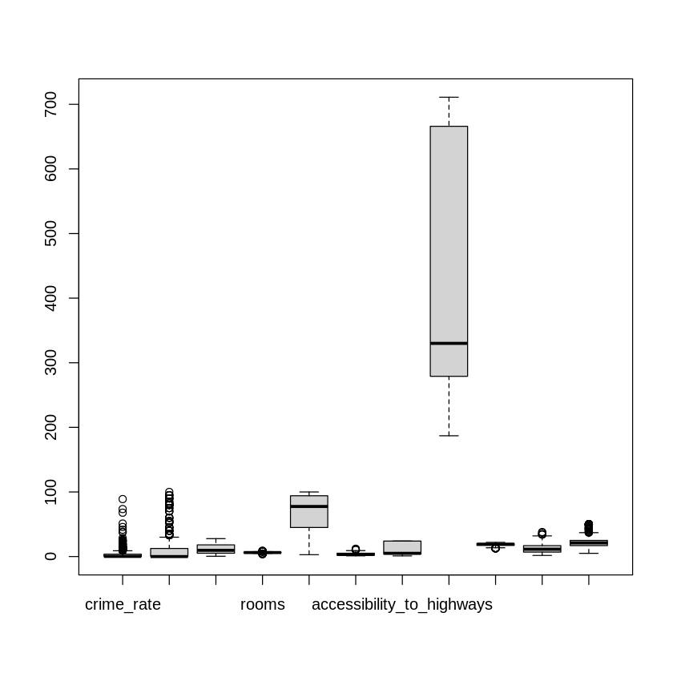

```r
boxplot(df.updated, vertical = TRUE)
```

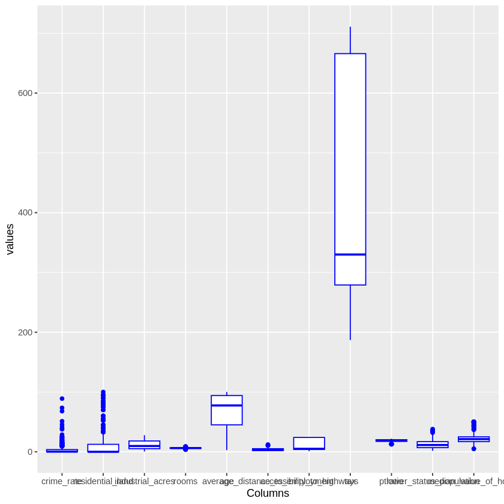

```r
library(ggplot2)
ggplot(stack(df.updated), aes(x = ind, y = values)) +
labs(x="Columns") +
geom_boxplot(fill = "white", colour = "blue")
```

## Adaptation

- Below code calculates house prices per number of rooms, and added as an aggreagted column.

```r
house_price_per_room <- (df.updated[11]*1000)/df.updated[4]
```

```r
df.updated['house_price_per_room'] <- house_price_per_room
head(df.updated)
```

A data.frame: 6 × 12

|  | crime_rate <dbl> | residential_land <dbl> | industrial_acres <dbl> | rooms <dbl> | age <dbl> | average_distance_to_employment <dbl> | accessibility_to_highways <int> | tax <int> | ptratio <dbl> | lower_status_population <dbl> | median_value_of_house <dbl> | house_price_per_room <dbl> |
| --- | --- | --- | --- | --- | --- | --- | --- | --- | --- | --- | --- | --- |
| 1 | 0.00632 | 18 | 2.31 | 6.575 | 65.2 | 4.0900 | 1 | 296 | 15.3 | 4.98 | 24.0 | 3650.190 |
| 2 | 0.02731 | 0 | 7.07 | 6.421 | 78.9 | 4.9671 | 2 | 242 | 17.8 | 9.14 | 21.6 | 3363.962 |
| 3 | 0.02729 | 0 | 7.07 | 7.185 | 61.1 | 4.9671 | 2 | 242 | 17.8 | 4.03 | 34.7 | 4829.506 |
| 4 | 0.03237 | 0 | 2.18 | 6.998 | 45.8 | 6.0622 | 3 | 222 | 18.7 | 2.94 | 33.4 | 4772.792 |
| 5 | 0.06905 | 0 | 2.18 | 7.147 | 54.2 | 6.0622 | 3 | 222 | 18.7 | 5.33 | 36.2 | 5065.062 |
| 6 | 0.02985 | 0 | 2.18 | 6.430 | 58.7 | 6.0622 | 3 | 222 | 18.7 | 5.21 | 28.7 | 4463.453 |

- Below code calcuates the ratio of average distance to 5 employment center to the index of accesibility to radial highway to compare the availabilty and effectiveness of transit.

```r
average_distance_by_accesstohighway <- df.updated[6]/df.updated[7]
```

```r
df.updated['average_distance_by_accesstohighway'] <- average_distance_by_accesstohighway
head(df.updated)
```

A data.frame: 6 × 13

|  | crime_rate <dbl> | residential_land <dbl> | industrial_acres <dbl> | rooms <dbl> | age <dbl> | average_distance_to_employment <dbl> | accessibility_to_highways <int> | tax <int> | ptratio <dbl> | lower_status_population <dbl> | median_value_of_house <dbl> | house_price_per_room <dbl> | average_distance_by_accesstohighway <dbl> |
| --- | --- | --- | --- | --- | --- | --- | --- | --- | --- | --- | --- | --- | --- |
| 1 | 0.00632 | 18 | 2.31 | 6.575 | 65.2 | 4.0900 | 1 | 296 | 15.3 | 4.98 | 24.0 | 3650.190 | 4.090000 |
| 2 | 0.02731 | 0 | 7.07 | 6.421 | 78.9 | 4.9671 | 2 | 242 | 17.8 | 9.14 | 21.6 | 3363.962 | 2.483550 |
| 3 | 0.02729 | 0 | 7.07 | 7.185 | 61.1 | 4.9671 | 2 | 242 | 17.8 | 4.03 | 34.7 | 4829.506 | 2.483550 |
| 4 | 0.03237 | 0 | 2.18 | 6.998 | 45.8 | 6.0622 | 3 | 222 | 18.7 | 2.94 | 33.4 | 4772.792 | 2.020733 |
| 5 | 0.06905 | 0 | 2.18 | 7.147 | 54.2 | 6.0622 | 3 | 222 | 18.7 | 5.33 | 36.2 | 5065.062 | 2.020733 |
| 6 | 0.02985 | 0 | 2.18 | 6.430 | 58.7 | 6.0622 | 3 | 222 | 18.7 | 5.21 | 28.7 | 4463.453 | 2.020733 |

# Visualization

```r
install.packages("psych")
install.packages("rgl")
install.packages("plot3D")
install.packages("reshape")
install.packages("scatterplot3d")
install.packages("ggplot2")
```

```r
library(psych)
library(rgl)
library("plot3D")
library(reshape)
library(scatterplot3d)
library(ggplot2)
```

- This is a 2D density plots the relation between two numerical values of rooms per house and the price of house per room.

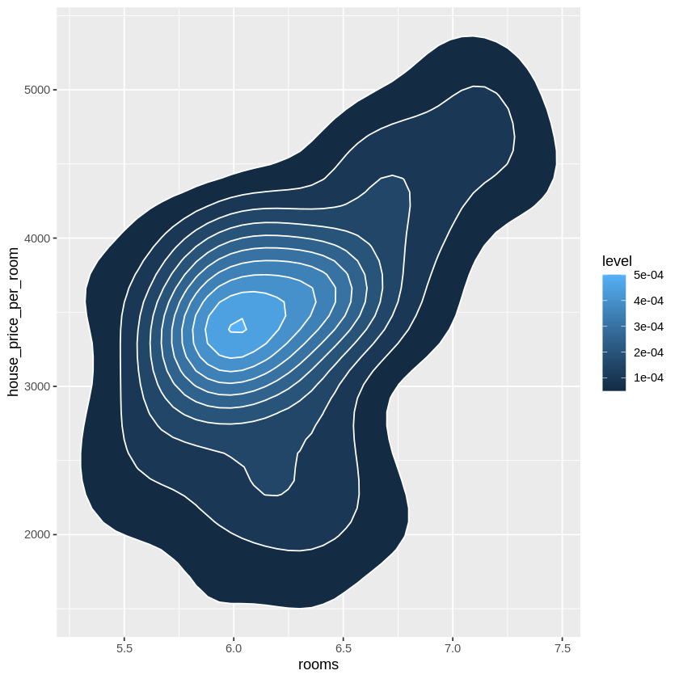

```r
ggplot (df.updated, aes (x = rooms, y = house_price_per_room, colour = "pink")) +
        stat_density2d (aes(fill = ..level..), geom = "polygon", colour="white")
```

- We have used scatter plot from the df.updated data frame same as the above variables. From this plot we can observe that rooms against price of house per room shows positive correlation. It can also be seen that most of the price range for house per room lies between $2000 to $4000.

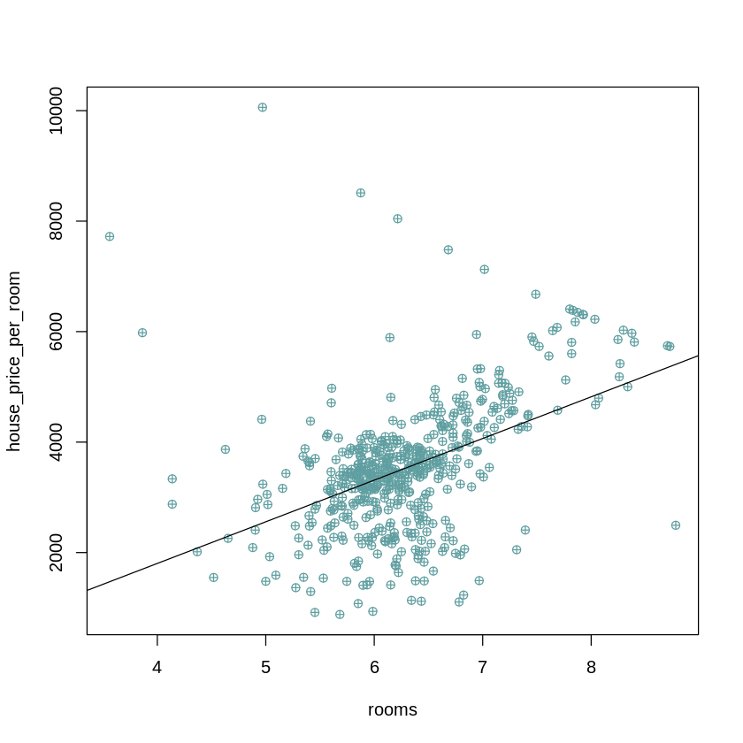

```r
scat <- lm(house_price_per_room ~ rooms, data = df.updated)
plot(house_price_per_room ~ rooms, data = df.updated, pch=10,col = "cadetblue")
abline(scat)
```

- Below is a histogram represnting tax, as it can be seen that range between 250 to 300 with 185 highest value.

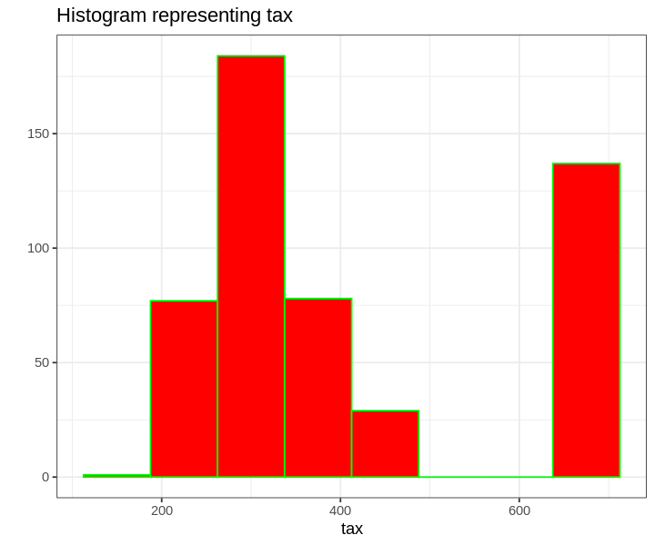

```r
options(repr.plot.width = 6, repr.plot.height = 5)
ggplot(df.updated, aes(tax)) + geom_histogram(binwidth = 75, color = "green", fill = "red") + theme_bw() +
labs(title = "Histogram representing tax", x = "tax", y = "")
```

- A 3D scatter plot representing age of the house vs non retail acres vs tax.

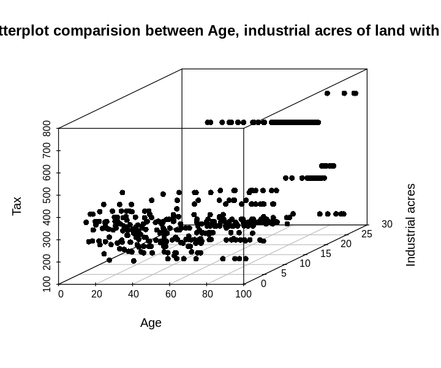

```r
scatterplot3d(x = df.updated$age, y=df.updated$industrial_acres, z=df.updated$tax ,
            main = "Scatterplot comparision between Age, industrial acres of land with tax ",
            pch = 16, xlab = "Age", ylab = "Industrial acres", zlab = "Tax")
```

# Linear Regression

## 6) Explore Correlations

```r
install.packages("corrplot")
library("corrplot")
```

```r
source("http://www.sthda.com/upload/rquery_cormat.r")
```

```r
corr <- df.updated[,c(1,3:11)]
head(corr)
```

A data.frame: 6 × 10

|  | crime_rate <dbl> | industrial_acres <dbl> | rooms <dbl> | age <dbl> | average_distance_to_employment <dbl> | accessibility_to_highways <int> | tax <int> | ptratio <dbl> | lower_status_population <dbl> | median_value_of_house <dbl> |
| --- | --- | --- | --- | --- | --- | --- | --- | --- | --- | --- |
| 1 | 0.00632 | 2.31 | 6.575 | 65.2 | 4.0900 | 1 | 296 | 15.3 | 4.98 | 24.0 |
| 2 | 0.02731 | 7.07 | 6.421 | 78.9 | 4.9671 | 2 | 242 | 17.8 | 9.14 | 21.6 |
| 3 | 0.02729 | 7.07 | 7.185 | 61.1 | 4.9671 | 2 | 242 | 17.8 | 4.03 | 34.7 |
| 4 | 0.03237 | 2.18 | 6.998 | 45.8 | 6.0622 | 3 | 222 | 18.7 | 2.94 | 33.4 |
| 5 | 0.06905 | 2.18 | 7.147 | 54.2 | 6.0622 | 3 | 222 | 18.7 | 5.33 | 36.2 |
| 6 | 0.02985 | 2.18 | 6.430 | 58.7 | 6.0622 | 3 | 222 | 18.7 | 5.21 | 28.7 |

```r
rquery.cormat(corr, type = "flatten", graph = FALSE)
```

**$r**

A data.frame: 45 × 4

| row <chr> | column <chr> | cor <dbl> | p <dbl> |
| --- | --- | --- | --- |
| ptratio | lower_status_population | 0.37 | 3.0e-18 |
| ptratio | industrial_acres | 0.38 | 3.8e-19 |
| lower_status_population | industrial_acres | 0.60 | 1.4e-51 |
| ptratio | age | 0.26 | 2.3e-09 |
| lower_status_population | age | 0.60 | 2.8e-51 |
| industrial_acres | age | 0.64 | 8.4e-61 |
| ptratio | crime_rate | 0.29 | 2.9e-11 |
| lower_status_population | crime_rate | 0.46 | 2.7e-27 |
| industrial_acres | crime_rate | 0.41 | 1.5e-21 |
| age | crime_rate | 0.35 | 2.9e-16 |
| ptratio | accessibility_to_highways | 0.46 | 1.8e-28 |
| lower_status_population | accessibility_to_highways | 0.49 | 9.9e-32 |
| industrial_acres | accessibility_to_highways | 0.60 | 8.4e-50 |
| age | accessibility_to_highways | 0.46 | 2.4e-27 |
| crime_rate | accessibility_to_highways | 0.63 | 2.7e-56 |
| ptratio | tax | 0.46 | 5.7e-28 |
| lower_status_population | tax | 0.54 | 2.6e-40 |
| industrial_acres | tax | 0.72 | 3.0e-82 |
| age | tax | 0.51 | 2.6e-34 |
| crime_rate | tax | 0.58 | 2.4e-47 |
| accessibility_to_highways | tax | 0.91 | 4.1e-195 |
| ptratio | average_distance_to_employment | -0.23 | 1.2e-07 |
| lower_status_population | average_distance_to_employment | -0.50 | 6.4e-33 |
| industrial_acres | average_distance_to_employment | -0.71 | 3.6e-78 |
| age | average_distance_to_employment | -0.75 | 9.9e-92 |
| crime_rate | average_distance_to_employment | -0.38 | 8.5e-19 |
| accessibility_to_highways | average_distance_to_employment | -0.49 | 1.4e-32 |
| tax | average_distance_to_employment | -0.53 | 1.0e-38 |
| ptratio | rooms | -0.36 | 1.6e-16 |
| lower_status_population | rooms | -0.61 | 1.0e-53 |
| industrial_acres | rooms | -0.39 | 5.3e-20 |
| age | rooms | -0.24 | 4.5e-08 |
| crime_rate | rooms | -0.22 | 6.3e-07 |
| accessibility_to_highways | rooms | -0.21 | 1.9e-06 |
| tax | rooms | -0.29 | 2.1e-11 |
| average_distance_to_employment | rooms | 0.21 | 3.2e-06 |
| ptratio | median_value_of_house | -0.51 | 1.6e-34 |
| lower_status_population | median_value_of_house | -0.74 | 5.1e-88 |
| industrial_acres | median_value_of_house | -0.48 | 4.9e-31 |
| age | median_value_of_house | -0.38 | 1.6e-18 |
| crime_rate | median_value_of_house | -0.39 | 1.2e-19 |
| accessibility_to_highways | median_value_of_house | -0.38 | 5.5e-19 |
| tax | median_value_of_house | -0.47 | 5.6e-29 |
| average_distance_to_employment | median_value_of_house | 0.25 | 1.2e-08 |
| rooms | median_value_of_house | 0.70 | 2.5e-74 |

**$p**

NULL

**$sym**

NULL

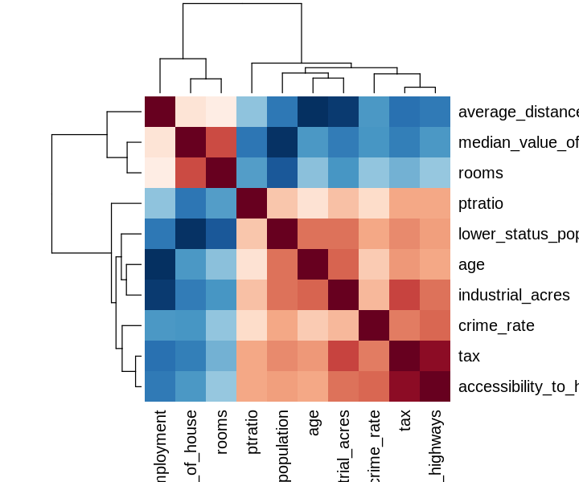

```r
cormat<-rquery.cormat(corr, graphType = "heatmap")
```

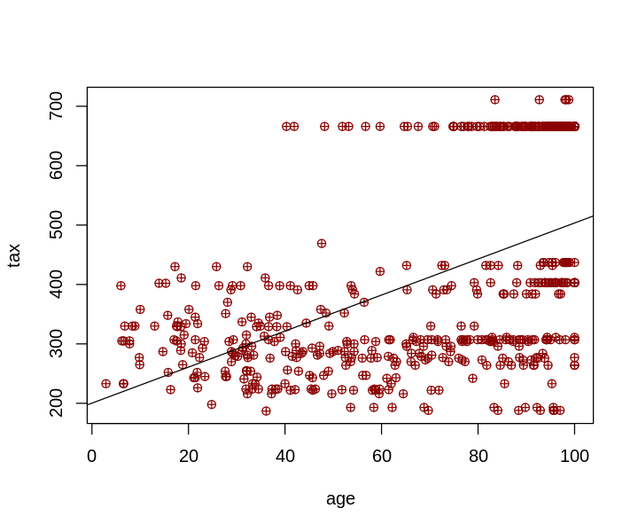

```r
scar <- lm(tax ~ age, data = df.updated)
plot(tax ~ age, data = df.updated, pch=10,col = "Red4")
abline(scar)
```

## 8) Simple linear regression

- In simple linear regression models we will use Adjusted R-squared to compare them, the higher the value the better correlation in our dataset.

In model 1 we have used price of house per room and the percentage of lower status of population to see if they interconnected any how and what's the correlation. - From the results we can see it has a negative correlation meaning as the population of lower status people increases the house prices drop.

$ Y = -114.8X1 + 4979.0$

**Adjusted R-squared** : 0.4851

```r
mod1 <- lm(house_price_per_room ~ lower_status_population, data = df.updated)
mod1
summary(mod1)
```

```
Call:
lm(formula = house_price_per_room ~ lower_status_population,
    data = df.updated)

Coefficients:
            (Intercept)  lower_status_population
                 4979.0                   -114.8
```

```
Call:
lm(formula = house_price_per_room ~ lower_status_population,
    data = df.updated)

Residuals:
    Min      1Q  Median      3Q     Max
-2100.8  -546.0  -157.3   293.3  5455.7

Coefficients:
                        Estimate Std. Error t value Pr(>|t|)
(Intercept)             4978.978     76.381   65.19   <2e-16 ***
lower_status_population -114.811      5.258  -21.83   <2e-16 ***
---
Signif. codes:  0 ‘***’ 0.001 ‘**’ 0.01 ‘*’ 0.05 ‘.’ 0.1 ‘ ’ 1

Residual standard error: 843.8 on 504 degrees of freedom
Multiple R-squared:  0.4861,	Adjusted R-squared:  0.4851
F-statistic: 476.7 on 1 and 504 DF,  p-value: < 2.2e-16
```

In **Model 2** we have used price of house per room and the industrial acres to see if they interconnected any how and what's the correlation. - From the results we can see it has a negative correlation meaning as the proportion of non-retail business acres per town increases the house prices decreases with it.

$ Y = -76.19X1 + 4374.77 $

**Adjusted R-squared** : 0.196

```r
mod2 <- lm(house_price_per_room ~ industrial_acres, data = df.updated)
mod2
summary(mod2)
```

```
Call:
lm(formula = house_price_per_room ~ industrial_acres, data = df.updated)

Coefficients:
     (Intercept)  industrial_acres
         4374.77            -76.19
```

```
Call:
lm(formula = house_price_per_room ~ industrial_acres, data = df.updated)

Residuals:
    Min      1Q  Median      3Q     Max
-2115.9  -635.5  -109.0   449.3  7064.6

Coefficients:
                 Estimate Std. Error t value Pr(>|t|)
(Intercept)       4374.77      89.44   48.91   <2e-16 ***
industrial_acres   -76.19       6.84  -11.14   <2e-16 ***
---
Signif. codes:  0 ‘***’ 0.001 ‘**’ 0.01 ‘*’ 0.05 ‘.’ 0.1 ‘ ’ 1

Residual standard error: 1054 on 504 degrees of freedom
Multiple R-squared:  0.1976,	Adjusted R-squared:  0.196
F-statistic: 124.1 on 1 and 504 DF,  p-value: < 2.2e-16
```

In **Model 3** we have used price of house per room and tax to see if they interconnected any how and what's the correlation. - From the results we can see it has a slight negetive correlation meaning as the taxes increase the price of the house drops.

$ Y = -3.188X1 + 4827.8$

**Adjusted R-squared**: 0.2072

```r
mod3 <- lm(house_price_per_room ~ tax, data = df.updated)

mod3
summary(mod3)
```

```
Call:
lm(formula = house_price_per_room ~ tax, data = df.updated)

Coefficients:
(Intercept)          tax
   4827.788       -3.188
```

```
Call:
lm(formula = house_price_per_room ~ tax, data = df.updated)

Residuals:
    Min      1Q  Median      3Q     Max
-1984.0  -616.9  -187.6   461.9  7355.9

Coefficients:
             Estimate Std. Error t value Pr(>|t|)
(Intercept) 4827.7882   122.0808   39.55   <2e-16 ***
tax           -3.1881     0.2765  -11.53   <2e-16 ***
---
Signif. codes:  0 ‘***’ 0.001 ‘**’ 0.01 ‘*’ 0.05 ‘.’ 0.1 ‘ ’ 1

Residual standard error: 1047 on 504 degrees of freedom
Multiple R-squared:  0.2088,	Adjusted R-squared:  0.2072
F-statistic:   133 on 1 and 504 DF,  p-value: < 2.2e-16
```

$ Y = -2.157X1 + 62.345$

**Adjusted R-squared**: 0.2564

```r
mod4 <- lm(median_value_of_house ~ ptratio, data = df.updated)
mod4
summary(mod4)
```

```
Call:
lm(formula = median_value_of_house ~ ptratio, data = df.updated)

Coefficients:
(Intercept)      ptratio
     62.345       -2.157
```

```
Call:
lm(formula = median_value_of_house ~ ptratio, data = df.updated)

Residuals:
     Min       1Q   Median       3Q      Max
-18.8342  -4.8262  -0.6426   3.1571  31.2303

Coefficients:
            Estimate Std. Error t value Pr(>|t|)
(Intercept)   62.345      3.029   20.58   <2e-16 ***
ptratio       -2.157      0.163  -13.23   <2e-16 ***
---
Signif. codes:  0 ‘***’ 0.001 ‘**’ 0.01 ‘*’ 0.05 ‘.’ 0.1 ‘ ’ 1

Residual standard error: 7.931 on 504 degrees of freedom
Multiple R-squared:  0.2578,	Adjusted R-squared:  0.2564
F-statistic: 175.1 on 1 and 504 DF,  p-value: < 2.2e-16
```

In **Model 5** we have used house price per room and age to see if they interconnected any how and what's the correlation. - From the results we can see this too has a negative correlation meaning the house price rate is decrease, when the age of house is increasing. It is mainly due to depreciating nature, it loses it value over time.

$ Y = -15.9X1 +4616.6 $

**Adjusted R-squared**: 0.1432

```r
mod5 <- lm(house_price_per_room ~ age , data = df.updated)
mod5
summary(mod5)
```

```
Call:
lm(formula = house_price_per_room ~ age, data = df.updated)

Coefficients:
(Intercept)          age
     4616.6        -15.9
```

```
Call:
lm(formula = house_price_per_room ~ age, data = df.updated)

Residuals:
    Min      1Q  Median      3Q     Max
-2303.0  -628.4  -165.4   398.1  7033.8

Coefficients:
            Estimate Std. Error t value Pr(>|t|)
(Intercept) 4616.617    127.540   36.20   <2e-16 ***
age          -15.900      1.721   -9.24   <2e-16 ***
---
Signif. codes:  0 ‘***’ 0.001 ‘**’ 0.01 ‘*’ 0.05 ‘.’ 0.1 ‘ ’ 1

Residual standard error: 1089 on 504 degrees of freedom
Multiple R-squared:  0.1449,	Adjusted R-squared:  0.1432
F-statistic: 85.38 on 1 and 504 DF,  p-value: < 2.2e-16
```

```r
cat("Adjusted R-squared value of Model 1:", summary(mod1)$adj.r.squared,
    "\nAdjusted R-squared value of Model 2:", summary(mod2)$adj.r.squared,
    "\nAdjusted R-squared value of Model 3:", summary(mod3)$adj.r.squared,
    "\nAdjusted R-squared value of Model 4:", summary(mod4)$adj.r.squared,
    "\nAdjusted R-squared value of Model 5:", summary(mod5)$adj.r.squared)
```

```
Adjusted R-squared value of Model 1: 0.4850735
Adjusted R-squared value of Model 2: 0.1959707
Adjusted R-squared value of Model 3: 0.2072133
Adjusted R-squared value of Model 4: 0.2563748
Adjusted R-squared value of Model 5: 0.1431638
```

- From the above output, it can be seen that **Model 1** performed well and achieved highest **Adjusted R-squared 0.485**.
- Below is the Model 1 plot which shows a negative correlation between price of house per room with the percentage of lower status population.

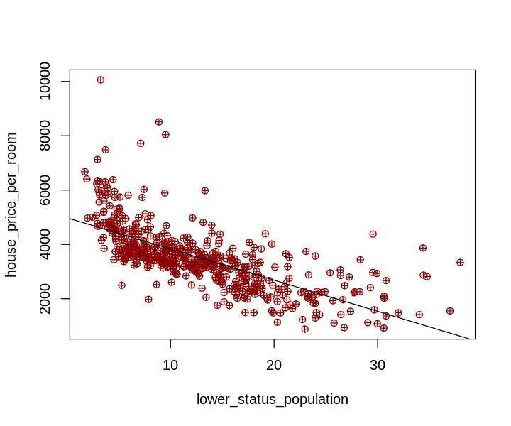

```r
plot(house_price_per_room ~ lower_status_population, data = df.updated, pch=10,col = "Red4")
abline(mod1)
```

## 9) Multiple linear

- This is the multi-linear regression of model 1 which predicts the price of the house per room against tax, non-retail industrial acres, number of rooms and age of the house.

  $ Y = -1.8X1 - 5.2X2 + 545.0X3 - 6.2X4 + 1339.1 $

```r
mulline1 <- lm(house_price_per_room ~ tax + industrial_acres + rooms + age, data =df.updated )
summary(mulline1)
```

```
Call:
lm(formula = house_price_per_room ~ tax + industrial_acres +
    rooms + age, data = df.updated)

Residuals:
    Min      1Q  Median      3Q     Max
-2041.2  -462.0  -135.4   330.3  7958.1

Coefficients:
                  Estimate Std. Error t value Pr(>|t|)
(Intercept)      1339.1012   464.6784   2.882  0.00412 **
tax                -1.8468     0.3672  -5.030 6.85e-07 ***
industrial_acres   -5.1746    10.5117  -0.492  0.62274
rooms             545.0032    66.1546   8.238 1.53e-15 ***
age                -6.2184     1.9937  -3.119  0.00192 **
---
Signif. codes:  0 ‘***’ 0.001 ‘**’ 0.01 ‘*’ 0.05 ‘.’ 0.1 ‘ ’ 1

Residual standard error: 960.8 on 501 degrees of freedom
Multiple R-squared:  0.3377,	Adjusted R-squared:  0.3324
F-statistic: 63.87 on 4 and 501 DF,  p-value: < 2.2e-16
```

```r
summary(mulline1)$coefficient
```

A matrix: 5 × 4 of type dbl

|  | Estimate | Std. Error | t value | Pr(>\|t\|) |
| --- | --- | --- | --- | --- |
| (Intercept) | 1339.101240 | 464.6783789 | 2.8817808 | 4.124038e-03 |
| tax | -1.846773 | 0.3671603 | -5.0298834 | 6.849082e-07 |
| industrial_acres | -5.174641 | 10.5117009 | -0.4922744 | 6.227410e-01 |
| rooms | 545.003235 | 66.1546234 | 8.2383242 | 1.534281e-15 |
| age | -6.218446 | 1.9936617 | -3.1191078 | 1.918439e-03 |

- This is the multi-linear regression model 2 which predicts the price of the house per room against lower status population, student-to-teacher ratio and crime rate.

  $ Y = -94.8X1 - 120.7X2 - 11.5X3 + 6996.5 $

```r
mulline2 <- lm(house_price_per_room ~ lower_status_population + ptratio + crime_rate, data =df.updated )
summary(mulline2)
```

```
Call:
lm(formula = house_price_per_room ~ lower_status_population +
    ptratio + crime_rate, data = df.updated)

Residuals:
    Min      1Q  Median      3Q     Max
-1739.0  -457.3  -159.7   255.9  5868.8

Coefficients:
                        Estimate Std. Error t value Pr(>|t|)
(Intercept)             6996.495    316.507  22.105  < 2e-16 ***
lower_status_population  -94.824      5.849 -16.212  < 2e-16 ***
ptratio                 -120.776     17.945  -6.731 4.63e-11 ***
crime_rate               -11.464      4.705  -2.436   0.0152 *
---
Signif. codes:  0 ‘***’ 0.001 ‘**’ 0.01 ‘*’ 0.05 ‘.’ 0.1 ‘ ’ 1

Residual standard error: 801.1 on 502 degrees of freedom
Multiple R-squared:  0.5386,	Adjusted R-squared:  0.5359
F-statistic: 195.4 on 3 and 502 DF,  p-value: < 2.2e-16
```

```r
summary(mulline2)$coefficient
```

A matrix: 4 × 4 of type dbl

|  | Estimate | Std. Error | t value | Pr(>\|t\|) |
| --- | --- | --- | --- | --- |
| (Intercept) | 6996.49534 | 316.506948 | 22.105345 | 4.027297e-76 |
| lower_status_population | -94.82366 | 5.848892 | -16.212243 | 7.630444e-48 |
| ptratio | -120.77640 | 17.944552 | -6.730533 | 4.627967e-11 |
| crime_rate | -11.46387 | 4.705444 | -2.436299 | 1.518509e-02 |

- This code display the output of the two multi-linear regression model.
- It is clearly seen that Model 2 out-performs Model 1 and also has higher **Adjusted r-sqaured of 0.536**

```r
cat("Adjusted R-squared value of Model 1:", summary(mulline1)$adj.r.squared,
    "\nAdjusted R-squared value of Model 2:", summary(mulline2)$adj.r.squared)
```

```
Adjusted R-squared value of Model 1: 0.332431
Adjusted R-squared value of Model 2: 0.5358885
```

# Project Report

This report is created by the finance group members of Analytic Computing class

> The **objective** of the our project is to help find the U.S census services concerning house in the area of the boston M.A. and factors that affect such as: crime_rate, industrial areas, age of house, taxes, percent of people having lower status and so on.

> To start with, we selected our dataset from kaggle website and the imported the data using the read.csv into our data frame.

> In the second step we did multiple **data exploration** such as: head(), tail() this prints the top 6 and bottom 6 lines of the data frame. Then after, we also printed the summary of the data frame which describes its overall structure starting with min value, max value as well as quartile range.

> The fourth step is **Adpatation** in which we estimated which two columns were related co-linearly. Then we calculated price of the house per room and the average distance to highway which shows the ease of access to transit.

> In the **correlation section**, we used library such as cormat to show as a summary as well as with heatmap how each of the selected column are correlated. Futher correlation was demonstrated with a scatter plot of proportion of owner occupied units built prior to 1940 against tax of the house and the output was what we predicted, a postive linear regression.

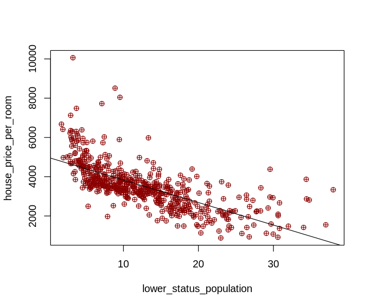

> In **multi-linear regression**, we are predicting the price of the house with the same factors as linear regression but combined/together unlike linear regression where we prdicted for individual factor. We created two models and out of which Model 2 was best fit with **adjusted r-sqaured value of 0.536**

> Originality of the project - This dataset was not created by us rather it was imported from Kaggle "https://www.kaggle.com/code/prasadperera/the-boston-housing-dataset". We did not refer or copy anyones work from the internet. But, there might be some scenarios where we could have used the same variables to predict the similar output as others on the web and also could have used the same visualization to present our graphs. All the notebooks that we came across were coded in python language and none in r language hence different approach to dataset as the library used also differs to some extent. Although we reached to stack overflow and other multiple website for reference, this work solely belongs to us.